# LDR text history analysis

Austin Chou

2018-10-28

The following is an exercise in R programming and data visualization as inspired by several Reddit posts (on r/dataisbeautiful). The text history from Whatsapp was downloaded on 10/01/18.

# Dataset curation

The following steps were taken to curate the dataset:  
* Remove “image omitted”, “Missed voice call”, “audio omitted”, “video omitted”, “GIF omitted”, “document omitted” entries.  
* Recombine entries that were incorrectly split by using “” (newline) as the original separator when reading the txt file.  
* Divide the entries into specific columns:  
-DATE  
-TIME  
-PERSON  
-TEXT  
* Remove PERSONS who are not the primary texters  
* Remove emoticon characters  
* Recombine entries that are actually part of the same quoted chat entry  
* Derive YEAR, HOUR, day of the week (weekday), number of characters (num_char), and number of words (num_words) of each entry

```r
history = read.table(file = "AC_ET_history.txt",
                     sep = "\n",
                     quote = "",
                     stringsAsFactors = FALSE)
cat(paste(nrow(history), "total entries in loaded text history"))

# Remove 'image omitted' entries
image_entries = dplyr::filter(history, grepl("image omitted", V1))
cat(paste(nrow(image_entries),
          "'image omitted' entries; removed; removed from dataset"))
history_a = dplyr::setdiff(history, image_entries)

# Remove 'Missed voice call' entries
missed_calls = dplyr::filter(history_a, grepl("â€ŽMissed voice call", V1))
cat(paste(nrow(missed_calls),
          "'Missed voice call' entries; removed from dataset"))
history_a = dplyr::setdiff(history_a, missed_calls)

# Remove 'audio omitted' entries
audio_entries = dplyr::filter(history_a, grepl("audio omitted", V1))
cat(paste(nrow(audio_entries),
          "'audio omitted' entries; removed from dataset"))
history_a = dplyr::setdiff(history_a, audio_entries)

# Remove 'video omitted' entries
video_entries = dplyr::filter(history_a, grepl("video omitted", V1))
cat(paste(nrow(missed_calls),
          "'video omitted' entries; removed from dataset"))
history_a = dplyr::setdiff(history_a, video_entries)

# Remove 'GIF omitted' entries
gif_entries = dplyr::filter(history_a, grepl("GIF omitted", V1))
cat(paste(nrow(missed_calls),
          "'GIF omitted' entries; removed from dataset"))
history_a = dplyr::setdiff(history_a, gif_entries)

# Remove 'document omitted' entries
doc_entries = dplyr::filter(history_a, grepl("document omitted", V1))
cat(paste(nrow(doc_entries),
          "'document omitted' entries; removed from dataset"))
history_a = dplyr::setdiff(history_a, doc_entries)

cat(paste(nrow(history_a), "entries after removing 'omitted' classification entries"))
```

```r
# Check what rows don't begin with "[" don't actually have the date-person-text
#  format that we are looking for each row
x = dplyr::filter(history_a, substring(V1,1,1) != "[")
cat(paste(nrow(x), "entries don't start with '['"))

cat("Entries that don't start with '[' but include the '[' character (potentially have a time - person - text entry in the loaded entry):")
print(dplyr::filter(x, grepl("\\[", V1)) %>% data.table())
```

```r
# If a text entry doesn't start with "[", it was a new line within a longer text
#  append the entry to the previous entry.
# Use a while loop to check each entry. If the entry doesn't start with "[",
#  then concatenate it to the previous entry
z = data.frame("V1" = NA)

print(Sys.time())
index = 1
while (index <= nrow(history_a)) {
     # Check if current entry doesn't start with "["
     if (index > 1 & substring(history_a$V1[index], 1, 1) != "[") {
          history_a$V1[index - 1] = paste(history_a$V1[index - 1],
                                          history_a$V1[index])

          # Recordkeeping purposes
          z = rbind(z, history_a[index,])

          # Remove the entry that just got attached
          history_a = history_a[-c(index), , drop = FALSE] #Drop keeps the data-
          #frame format
     } else {
          index = index + 1
     }

     #if (index %% 1000 == 0) {
     #     print(index)
     #}
}
print(Sys.time())

z = z[!is.na(z$V1),] %>%
     as.data.frame()

cat(paste(nrow(history_a),"entries after remerging lines that belong to the same message"))
```

```r
# Split into DATE, TIME, PERSON, TEXT
print(Sys.time())
history_a = history_a %>%
     rowwise() %>%
     mutate("DATE" = strsplit(V1, split = "]") %>% #Get Time section
                 unlist() %>%
                 .[1] %>%
                 strsplit(split = ",") %>% #Get date
                 unlist() %>%
                 .[1] %>%
                 substring(first = 2),
            "TIME" = strsplit(V1, split = "]") %>% #Get Time section
                 unlist() %>%
                 .[1] %>%
                 strsplit(split = ",") %>% #Get clock time
                 unlist() %>%
                 .[2] %>%
                 trimws(),
            "PERSON" = strsplit(V1, split = "]") %>% #Get Name section
                 unlist() %>%
                 .[2:length(.)] %>% #In case there is a "]" in the text, we need to restitch the string
                 paste(collapse = "]") %>%
                 strsplit(split = ":") %>%
                 unlist() %>%
                 .[1] %>%
                 trimws() %>%
                 strsplit(split = " ") %>% #Keep first name only
                 unlist() %>%
                 .[1],
            "TEXT" = strsplit(V1, split = "]") %>% #Get Text section
                 unlist() %>%
                 .[2:length(.)] %>% #In case there is a "]" in the text, we need to restitch the string
                 paste(collapse = "]") %>%
                 strsplit(split = ":") %>%
                 unlist() %>%
                 .[2:length(.)] %>% #In case there is a ":" in the text, we need to restitch the string
                 paste(collapse = ":") %>%
                 trimws()) %>%
     as.data.frame()
print(Sys.time())

history_a = history_a[,colnames(history_a) != "V1"]
if (rewrite) {
     write.csv(history_a, file = "history_draft_1.csv", row.names = FALSE)
}
#history_a = read.csv("20181002_history_draft.csv", stringsAsFactors = FALSE)

#Convert TIME to 24hr clock instead of AM/PM. And remove seconds
history_a = history_a %>%
     rowwise() %>%
     mutate(TIME = strptime(TIME, format = "%I:%M:%S %p") %>%
                 format(format = "%H:%M:%S")) %>%
     as.data.frame()
```

```r
# Remove persons != Elaine or Austin
other_people = history_a[!(grepl("Elaine", history_a$PERSON) |
                                grepl("Austin", history_a$PERSON)),]
history_a = dplyr::setdiff(history_a, other_people)
cat(paste(nrow(other_people), "entries are quotes from others"))
cat(paste(nrow(history_a), "entries directly said by Elaine or Austin"))

#Readjust "Â Austin" to "Austin
history_a[grepl("Â", history_a$PERSON),"PERSON"] = "Austin"

#Remove entries lacking english characters and digits; usually emoticons
history_a$TEXT = lapply(history_a$TEXT,
                        iconv, from = "UTF-8", to = "ASCII", sub = "") %>%
     unlist()



# remove_odd_char = history_a[grepl("ðŸ˜™", history_a$TEXT),]
# history_a = history_a[!grepl("ðŸ˜™", history_a$TEXT),]
# cat(paste("After removing 'ðŸ˜™' entries:",
#             nrow(history_a),
#             "text entries remaining"))
cat(paste(nrow(history_a), "entries in text history"))
if (rewrite) {
     write.csv(history_a, file = "history_draft_2.csv", row.names = FALSE)
}
```

```r
# Remove any entries where TEXT == null
no_text = history_a[history_a$TEXT == "", ]
history_a = dplyr::setdiff(history_a, no_text)
cat(paste(nrow(history_a),
          "entries in text history after removing entries with no text"))

# More cleanup
#  Some entries are clearly quoted. They are converted with a format:
#  Date: m/y time
#  Time: NA
#  Person: person
#  Text: Text
index = 1
z = NA
print(Sys.time())
while (index < nrow(history_a)) {
     # Check if current entry follows the Date format
     if (index > 1 & is.na(history_a[index,"TIME"])) {
          #Combine the entry to one line and append to previous
          history_a[index-1, "TEXT"] = paste0(history_a[index-1,"TEXT"],
                                              " \n ",
                                              "[",
                                              history_a[index,"DATE"],
                                              "] ",
                                              history_a[index,"PERSON"],
                                              ": ",
                                              history_a[index,"TEXT"])
          # Recordkeeping purposes
          z = rbind(z, history_a[index,])

          # Remove the entry that just got attached
          history_a = history_a[-c(index), , drop = FALSE]
     } else {
          index = index + 1
     }
}
print(Sys.time())

cat(paste(nrow(history_a),
          "entries after remerging lines that are the same quote"))

if (rewrite) {
     write.csv(history_a, file = "history_draft_3.csv", row.names = FALSE)
}
```

```r
history_a = read.csv("history_draft_3.csv", stringsAsFactors = FALSE)

for_analysis = history_a %>%
     rowwise() %>%
     mutate(YEAR = mdy(DATE) %>% year(),
            HOUR = strptime(TIME, "%H:%M:%S") %>% hour(),
            weekday = weekdays(mdy(DATE)),
            num_char = nchar(TEXT),
            num_words = TEXT %>%
                 strsplit(split = " ") %>%
                 unlist() %>%
                 length()) %>%
     as.data.frame()

for_analysis = for_analysis %>%
     rowwise() %>%
     mutate(PERSON = ifelse(PERSON == "Austin",
                            "Him",
                            "Her")) %>%
     ungroup() %>%
     as.data.frame()


if (rewrite) {
     write.csv(for_analysis, file = "history_draft_4.csv", row.names = FALSE)
}
```

# Initial plots

```r
for_analysis = read.csv("history_draft_4.csv", stringsAsFactors = FALSE)
```

## Texts sent: By person

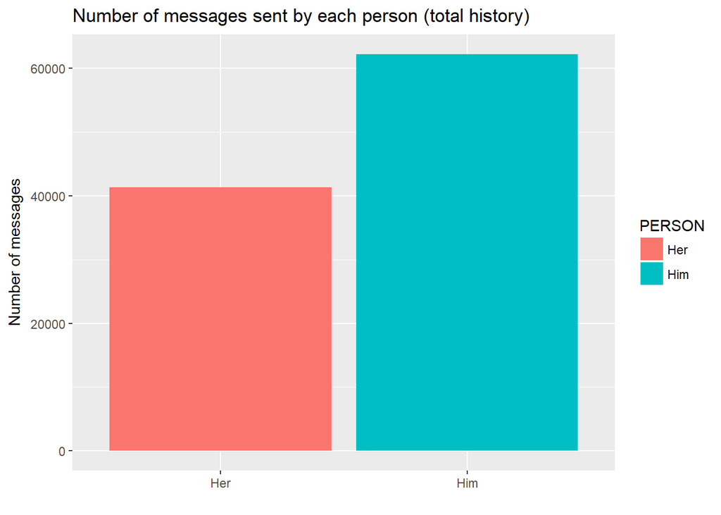

```r
# Plot how many texts were produced by each person
ggplot(data = for_analysis, aes(x = PERSON)) +
     geom_bar(aes(fill = PERSON)) +
     xlab("") +
     ylab("Number of messages") +
     ggtitle("Number of messages sent by each person (total history)")
```

## Texts sent: By time

### By Year

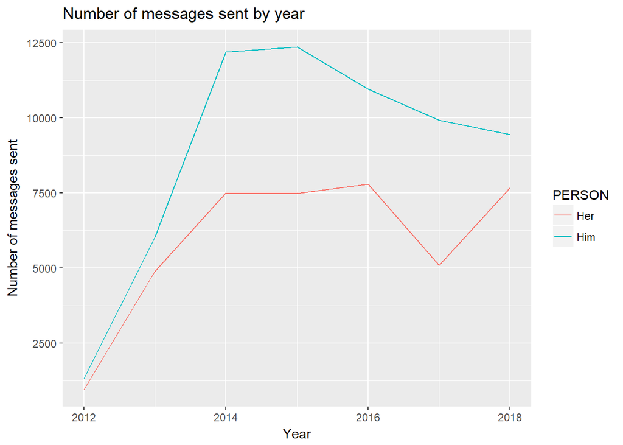

```r
a = table(for_analysis$PERSON, for_analysis$YEAR) %>%
     melt() %>%
     plyr::rename(c("Var1" = "PERSON",
                    "Var2" = "YEAR",
                    "value" = "COUNT"))

ggplot(data = a, aes(x = YEAR, y = COUNT, color = PERSON)) +
     geom_line() +
     xlab("Year") +
     ylab("Number of messages sent") +
     ggtitle("Number of messages sent by year")
```

### By Hour of day

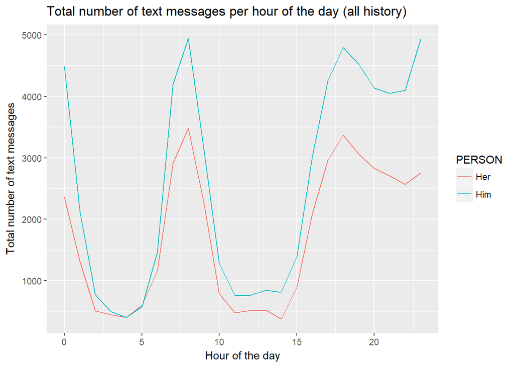

```r
a = table(for_analysis$PERSON, for_analysis$HOUR) %>%
     melt() %>%
     plyr::rename(c("Var1" = "PERSON",
                    "Var2" = "HOUR",
                    "value" = "COUNT"))

ggplot(data = a, aes(x = HOUR, y = COUNT, color = PERSON)) +
     geom_line() +
     xlab("Hour of the day") +
     ylab("Total number of text messages") +
     ggtitle("Total number of text messages per hour of the day (all history)")
```

### By day of the week

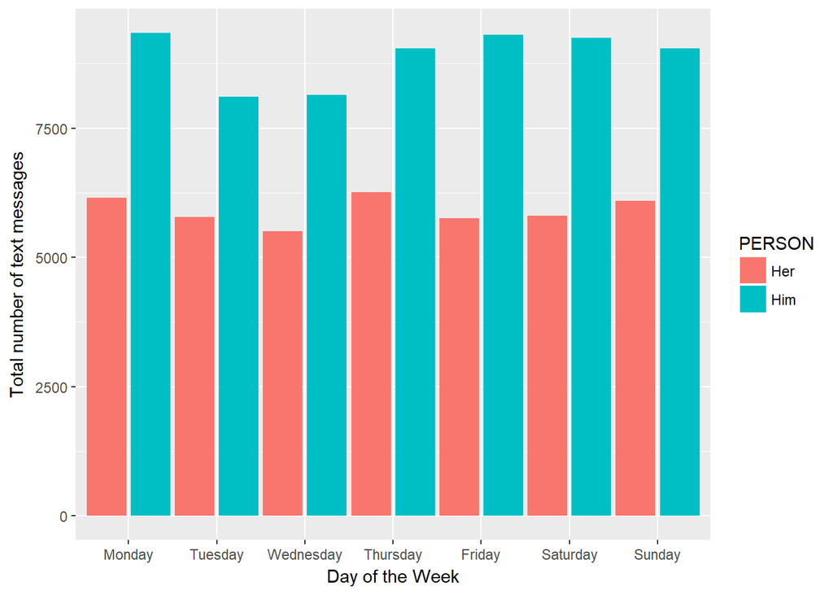

```r
for_analysis$weekday = factor(for_analysis$weekday,
                              levels = c("Monday", "Tuesday", "Wednesday", "Thursday",
                                         "Friday", "Saturday", "Sunday"))

ggplot(data = for_analysis, aes(x = weekday, fill = PERSON)) +
     geom_bar(position = position_dodge(width = 1)) +
     xlab("Day of the Week") +
     ylab("Total number of text messages")
```

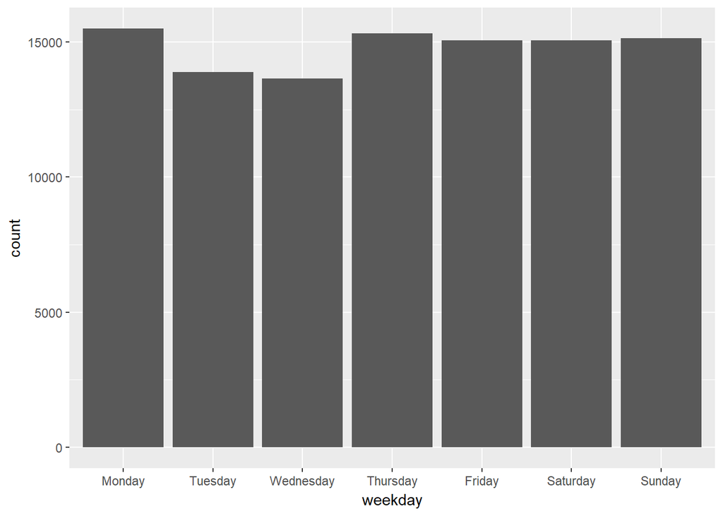

```r
ggplot(data = for_analysis, aes(x = weekday)) +
     geom_bar()
```

## Texts by length

### Number of characters

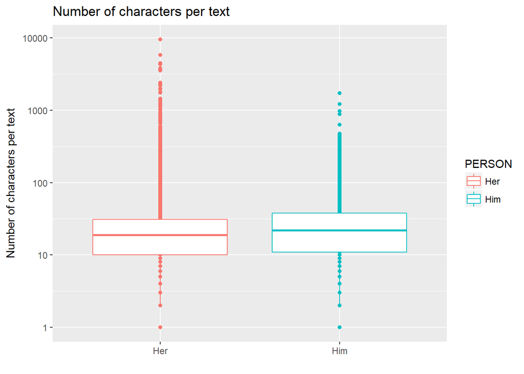

```r
ggplot(data = for_analysis, aes(x = PERSON, y = num_char, color = PERSON)) +
     geom_point() +
     geom_boxplot() +
     scale_y_log10(breaks = base_breaks()) +
     xlab("") +
     ylab("Number of characters per text") +
     ggtitle("Number of characters per text")
```

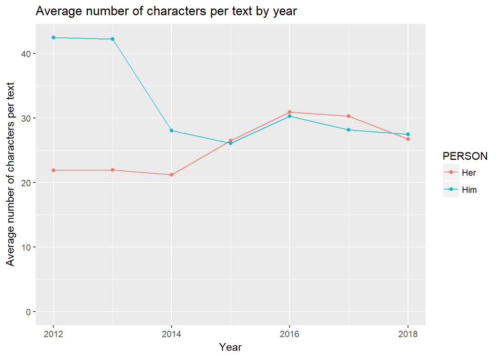

```r
ggplot(data = group_by(for_analysis, PERSON, YEAR) %>%
            summarise(mean_chars = mean(num_char)),
       aes(x = YEAR, y = mean_chars, color = PERSON)) +
     geom_point() +
     geom_line() +
     expand_limits(y = 0) +
     xlab("Year") +
     ylab("Average number of characters per text") +
     ggtitle("Average number of characters per text by year")
```

### Number of words

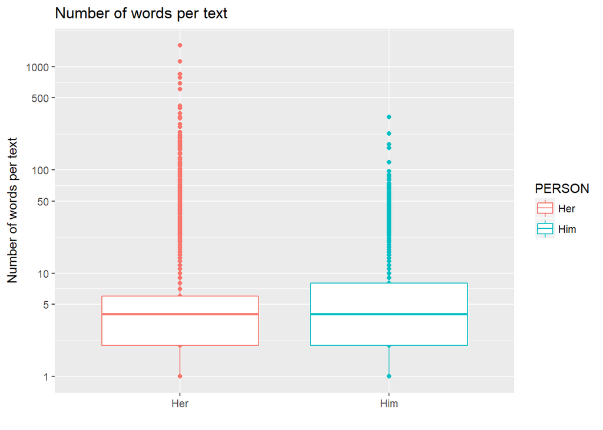

```r
ggplot(data = for_analysis, #%>%
            #rowwise() %>%
            #mutate(num_words = log10(num_words)),
       aes(x = PERSON, y = num_words, color = PERSON)) +
     geom_point() +
     geom_boxplot() +
     scale_y_log10(breaks = base_breaks()) +
     xlab("") +
     ylab("Number of words per text") +
     ggtitle("Number of words per text")
```

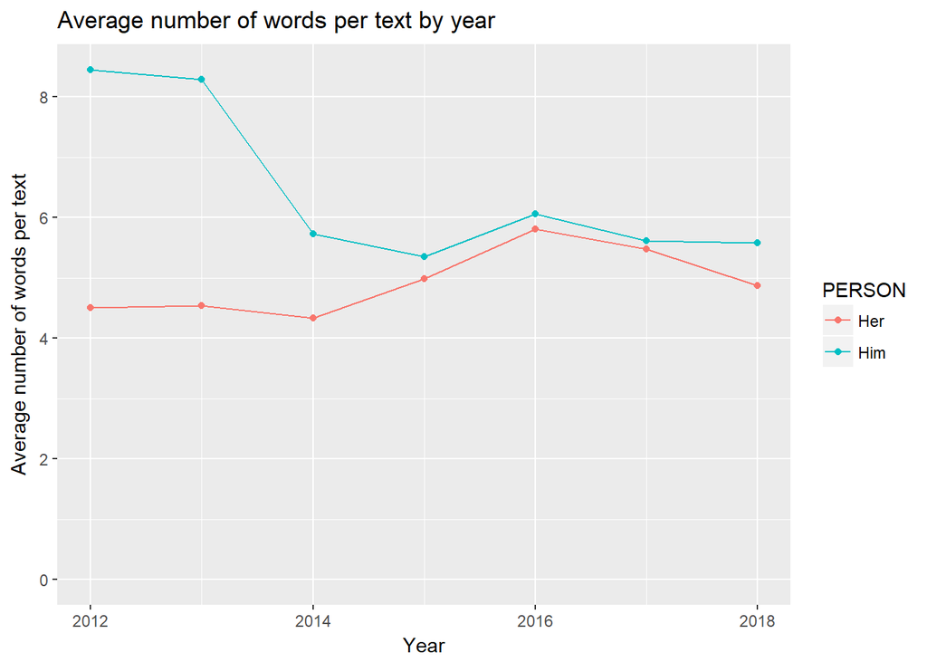

```r
ggplot(data = group_by(for_analysis, PERSON, YEAR) %>%
            summarise(mean_words = mean(num_words)),
       aes(x = YEAR, y = mean_words, color = PERSON)) +
     geom_point() +
     geom_line() +
     expand_limits(y = 0) +
     xlab("Year") +
     ylab("Average number of words per text") +
     ggtitle("Average number of words per text by year")
```

```r
t.test(for_analysis[for_analysis$PERSON == "Him","num_words"] %>% log10(),
       for_analysis[for_analysis$PERSON == "Her", "num_words"] %>% log10())
```

```
##
##  Welch Two Sample t-test
##
## data:  for_analysis[for_analysis$PERSON == "Him", "num_words"] %>% log10() and for_analysis[for_analysis$PERSON == "Her", "num_words"] %>% log10()
## t = 31.582, df = 94145, p-value < 2.2e-16
## alternative hypothesis: true difference in means is not equal to 0
## 95 percent confidence interval:
##  0.06851835 0.07758561
## sample estimates:
## mean of x mean of y
##  0.613066  0.540014
```

# Word usage analysis

## Curate Words

The following steps were taken to curate unique words:  
* Split each text entry by " "  
* Remove punctuation at the start or end of each word  
* Apply tolower  
* Keep only entries that have alphabet characters (removes punctuations that are part of emoticons)  
* Keep track of word frequency by PERSON  
* Remove single letter entries and stopwords

```r
# Clean load
for_analysis = read.csv("history_draft_4.csv", stringsAsFactors = FALSE)

remove_last_punct = function(string,
                             punctuations = c(".", ",", ";", ":", "/", "?", "!",
                                              ")", "'", '"')) {
     #' Take string and remove specific punctuations if they are the last
     #'  character in the string
     #'
     #' Input: String of interest (string),
     #'  list of punctuations to check and remove (list of strings)
     #' Output: Adjusted string

     while (substr(string, nchar(string), nchar(string)) %in% punctuations) {
          string = substr(string, 1, nchar(string)-1)
     }

     return(string)
}

remove_first_punct = function(string,
                              punctuations = c("(", "'", '"', ":")) {
     #' Take string and remove specific punctuations if they are the first
     #'  character in the string
     #'
     #' Input: String of interest (string),
     #'  list of punctuations to check and remove (list of strings)
     #' Output: Adjusted string

     if (substr(string, 1, 1) %in% punctuations) {
          return(substr(string, 2, nchar(string)))
     } else {
          return(string)
     }
}

# Create two separate datatables, then merge later
AC = data.frame("Word" = "",
                "Count" = 0)
ET = data.frame("Word" = "",
                "Count" = 0)

for (entry in 1:nrow(for_analysis)) {
     # # Track current entry
     # if (entry %% 1000 == 1) {
     #      cat(paste0("Entry [",entry, "] at Time:", Sys.time()))
     # }

     # Get current TEXT entry
     txt = for_analysis[entry, "TEXT"] %>%
          strsplit(split = " ") %>%
          unlist() %>%
          lapply(remove_last_punct) %>%
          lapply(remove_first_punct) %>%
          lapply(tolower) %>%
          unlist() %>%
          .[grepl("[[:alpha:]]", .)] #Keep only entries with alphabet characters
     # (removes numerics and punctuation-only)

     if (for_analysis[entry, "PERSON"] == "Her") {
          for (w in txt) {
               if (w %in% ET$Word) {
                    ET[ET$Word == w,"Count"] =
                         ET[ET$Word == w, "Count"] + 1
               } else {
                    ET = rbind(ET,
                               data.frame("Word" = w,
                                          "Count" = 1))
               }
          }
     } else {
          for (w in txt) {
               if (w %in% AC$Word) {
                    AC[AC$Word == w,"Count"] =
                         AC[AC$Word == w, "Count"] + 1
               } else {
                    AC = rbind(AC,
                               data.frame("Word" = w,
                                          "Count" = 1))
               }
          }
     }
}
AC = AC[AC$Word != "",]
ET = ET[ET$Word != "",]

# Restructure:
AC = rename(AC, "Him" = "Count")
ET = rename(ET, "Her" = "Count")

LDR_words = merge(AC, ET, by = "Word", all = TRUE)
LDR_words = LDR_words %>%
     rowwise() %>%
     mutate(Word = as.character(Word),
            Him = ifelse(is.na(Him), 0, Him),
            Her = ifelse(is.na(Her), 0, Her),
            Total = Him + Her) %>%
     as.data.frame()
```

```r
cat(paste("Number of unique words in text history:", nrow(LDR_words)))
cat("\n\n")

I = LDR_words[LDR_words$Word == "i",]

# Remove single letter words (mostly leftovers from smilies)
singles = LDR_words[nchar(LDR_words$Word) <= 1,]
LDR_words = LDR_words[nchar(LDR_words$Word) > 1,]
cat(paste("Number of unique words in text history with more than 1 character:",
          nrow(LDR_words)))
cat("\n\n")

# Remove stopwords
LDR_stopwords = LDR_words[LDR_words$Word %in% stopwords("en"),]
LDR_words = LDR_words[!LDR_words$Word %in% stopwords("en"),]
cat(paste("Number of unique words in text history after removing stopwords:",
          nrow(LDR_words)))
cat("\n\n")

if (rewrite) {
     write.csv(LDR_words, file = "LDR_word_freq.csv", row.names = FALSE)
}
```

## Top 10 words typed (Total)

```r
LDR_words = read.csv("LDR_word_freq.csv", stringsAsFactors = FALSE)
```

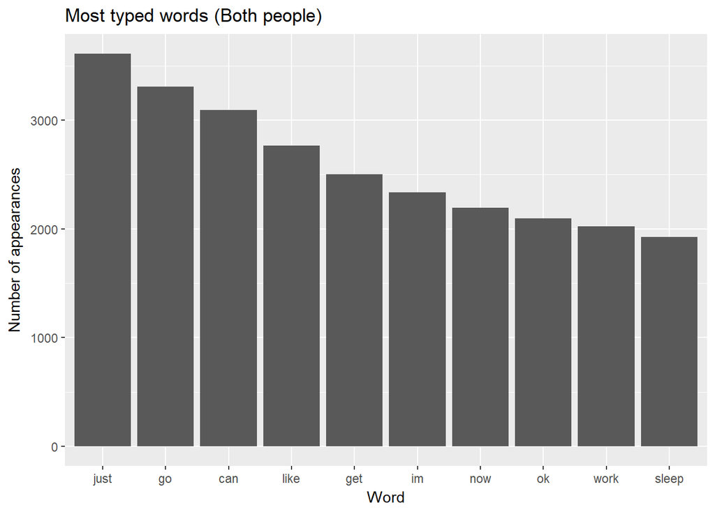

```r
p = ggplot(data = LDR_words[,c("Word","Total")] %>%
                .[order(.$Total, decreasing = TRUE),] %>%
                .[1:10,],
           aes(x = reorder(Word, -Total), y = Total)) +
     geom_bar(stat = "identity") +
     xlab("Word") +
     ylab("Number of appearances") +
     ggtitle("Most typed words (Both people)")

print(p)
```

## Top 10 words typed by Him

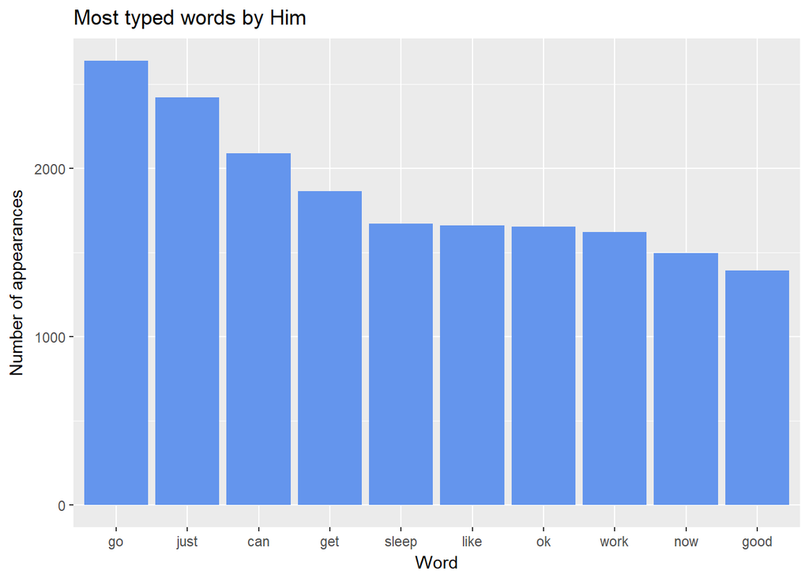

```r
p = ggplot(data = LDR_words[,c("Word","Him")] %>%
                .[order(.$Him, decreasing = TRUE),] %>%
                .[1:10,],
           aes(x = reorder(Word, -Him), y = Him)) +
     geom_bar(stat = "identity", fill = "cornflowerblue") +
     xlab("Word") +
     ylab("Number of appearances") +
     ggtitle("Most typed words by Him")

print(p)
```

## Top 10 words typed by Her

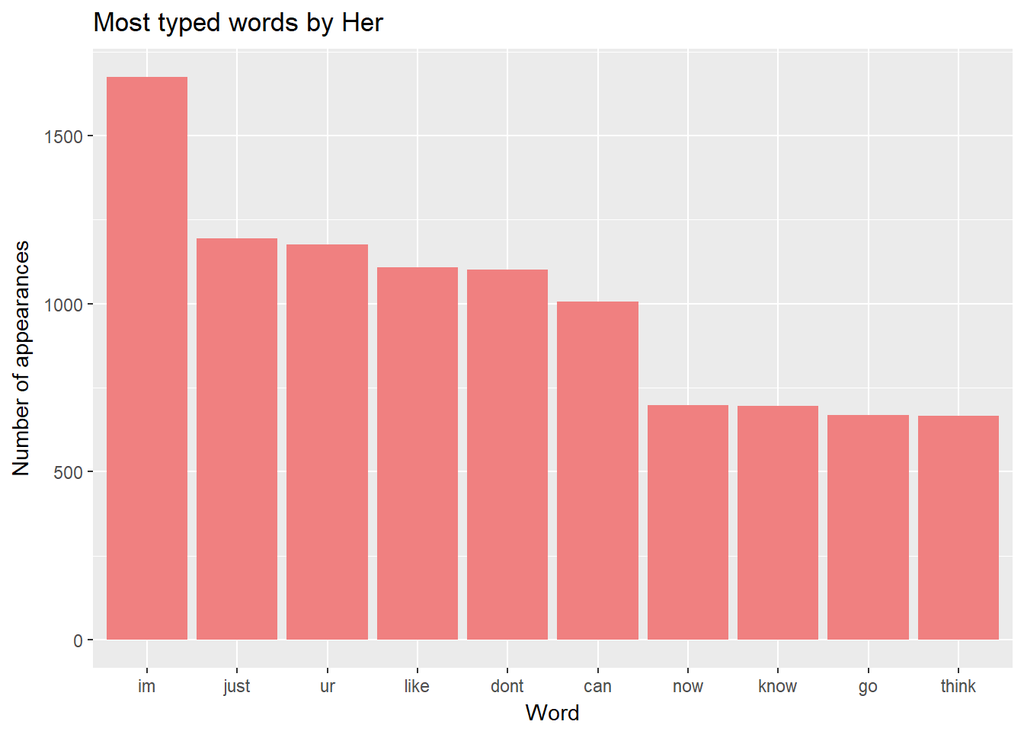

```r
p = ggplot(data = LDR_words[,c("Word","Her")] %>%
                .[order(.$Her, decreasing = TRUE),] %>%
                .[1:10,],
           aes(x = reorder(Word, -Her), y = Her)) +
     geom_bar(stat = "identity", fill = "lightcoral") + #lightseagreen
     xlab("Word") +
     ylab("Number of appearances") +
     ggtitle("Most typed words by Her")

print(p)
```

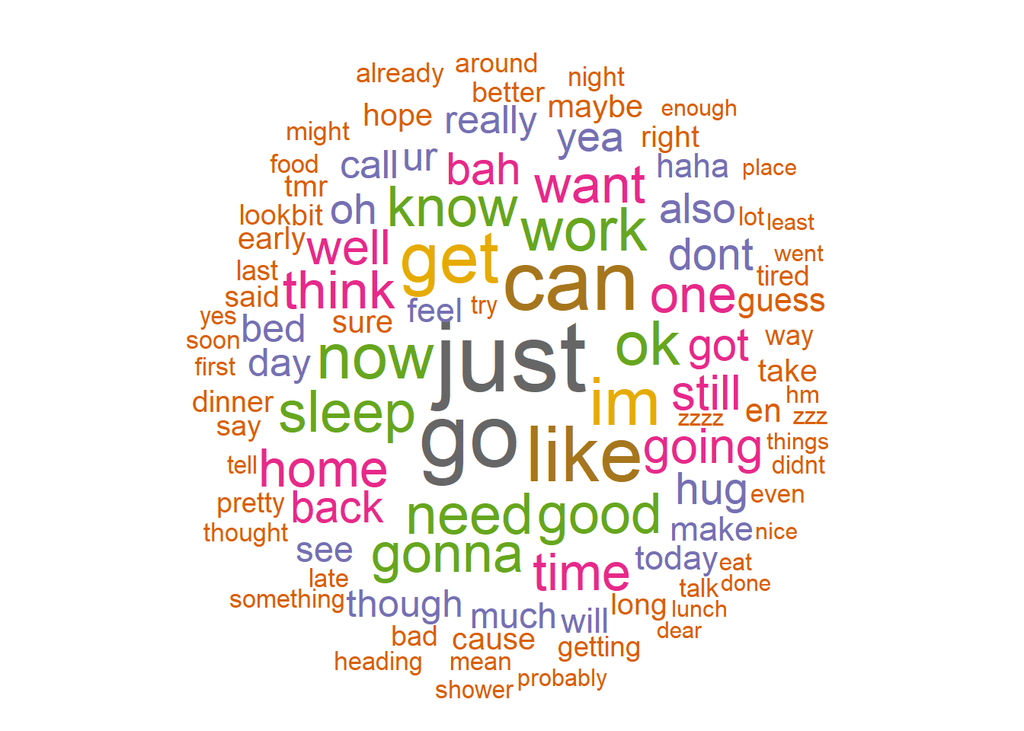

```r
wordcloud(words = LDR_words$Word,
          freq = LDR_words$Total,
          min.freq = 1,
          max.words = 100,
          random.order = FALSE,
          rot.per = 0,
          colors = brewer.pal(8, "Dark2")
)
```

## Word cloud based on word length

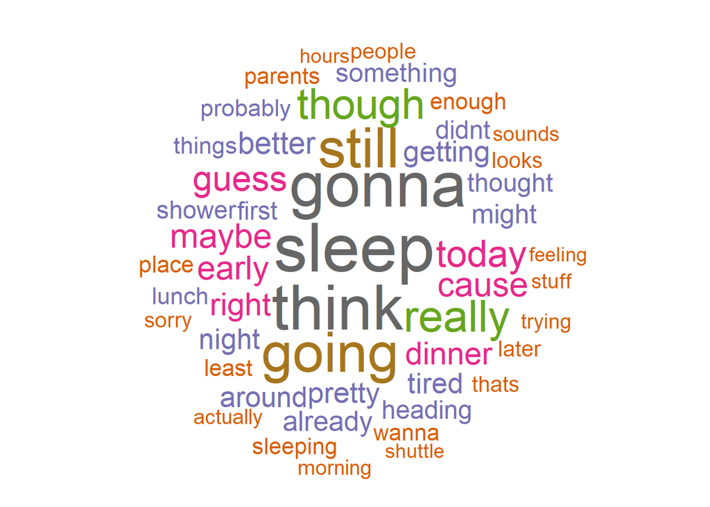

```r
min_length = 5
cut_LDR_words = LDR_words[nchar(LDR_words$Word) >= min_length,]

wordcloud(words = cut_LDR_words$Word,
          freq = cut_LDR_words$Total,
          min.freq = 1,
          max.words = 50,
          random.order = FALSE,
          rot.per = 0,
          colors = brewer.pal(8, "Dark2")
)
```

# Additional Corpus curation